*Transport Analytics Training Series - Last Revision: October 2022*

# Network Analytics

Now that we have a good handle on how basic pathfinding operations work, we can perform some further exploration of the properties of our network.

As this is a new notebook, we will have to load our dataset again:

```python
import networkx as nx
import pandas as pd

links = pd.read_csv('data-sioux-falls/siouxfalls_links.csv')
nodes = pd.read_csv('data-sioux-falls/siouxfalls_nodes.csv')
new_links = list(zip(links['from_node'], links['to_node']))

G = nx.Graph()
G.add_nodes_from(nodes['node'])
G.add_edges_from(new_links)
coords = list(zip(nodes['x'], nodes['y']))
pos = dict(zip(nodes['node'], coords))
```

### Part 1 - Degrees and centralities

Let's now see the degrees of our nodes:

```python
degrees = [G.degree(n) for n in G.nodes()]
degrees
```

```
[2, 2, 3, 3, 3, 3, 2, 4, 3, 5, 4, 3, 2, 3, 4, 4, 3, 3, 3, 4, 3, 4, 3, 3]
```

We can plot the distribution of degrees using `matplotlib`. To do this, we need to import it - as with the other libraries that we used, there happens to be yet another frequently used acronym for this library - `plt`.

```python
import matplotlib.pyplot as plt
```

We can plot a histogram using the `plt.hist()` command, passing the list in question as a parameter.

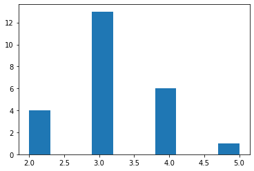

```python
plt.hist(degrees)
plt.show()
```

We can also obtain the various centrality values. Let's start with the degree centrality:

```python
nx.degree_centrality(G)
```

```
{1: 0.08695652173913043,
 2: 0.08695652173913043,
 3: 0.13043478260869565,
 4: 0.13043478260869565,
 5: 0.13043478260869565,
 6: 0.13043478260869565,
 7: 0.08695652173913043,
 8: 0.17391304347826086,
 9: 0.13043478260869565,
 10: 0.21739130434782608,
 11: 0.17391304347826086,
 12: 0.13043478260869565,
 13: 0.08695652173913043,
 14: 0.13043478260869565,
 15: 0.17391304347826086,
 16: 0.17391304347826086,
 17: 0.13043478260869565,
 18: 0.13043478260869565,
 19: 0.13043478260869565,
 20: 0.17391304347826086,
 21: 0.13043478260869565,
 22: 0.17391304347826086,
 23: 0.13043478260869565,
 24: 0.13043478260869565}
```

As we would like to compare the various centrality values it might be useful to store them in a new dataframe.

We can use the `pd.DataFrame()` command to initiate an empty dataframe.

```python
centralities = pd.DataFrame()
```

We can now start populating it by simply storing values to new columns.

```python
centralities['ID'] = G.nodes()
centralities['degree_centr'] = nx.degree_centrality(G).values()
centralities
```

|  | ID | degree_centr |
| --- | --- | --- |
| 1 | 1 | 0.086957 |
| 2 | 2 | 0.086957 |
| 3 | 3 | 0.130435 |
| 4 | 4 | 0.130435 |
| 5 | 5 | 0.130435 |
| 6 | 6 | 0.130435 |
| 7 | 7 | 0.086957 |
| 8 | 8 | 0.173913 |
| 9 | 9 | 0.130435 |
| 10 | 10 | 0.217391 |
| 11 | 11 | 0.173913 |
| 12 | 12 | 0.130435 |
| 13 | 13 | 0.086957 |
| 14 | 14 | 0.130435 |
| 15 | 15 | 0.173913 |
| 16 | 16 | 0.173913 |
| 17 | 17 | 0.130435 |
| 18 | 18 | 0.130435 |
| 19 | 19 | 0.130435 |
| 20 | 20 | 0.173913 |
| 21 | 21 | 0.130435 |
| 22 | 22 | 0.173913 |
| 23 | 23 | 0.130435 |
| 24 | 24 | 0.130435 |

Let's now obtain the rest of the centrality values that we obtained in the class.

```python
centralities['closeness_centr'] = nx.closeness_centrality(G).values()
centralities['betweenness_centr'] = nx.betweenness_centrality(G).values()
centralities['eigenvector_centr'] = nx.eigenvector_centrality(G).values()
centralities
```

|  | ID | degree_centr | closeness_centr | betweenness_centr | eigenvector_centr |
| --- | --- | --- | --- | --- | --- |
| 1 | 1 | 0.086957 | 0.264368 | 0.035244 | 0.034586 |
| 2 | 2 | 0.086957 | 0.267442 | 0.036797 | 0.041609 |
| 3 | 3 | 0.130435 | 0.306667 | 0.095285 | 0.078701 |
| 4 | 4 | 0.130435 | 0.348485 | 0.100838 | 0.128455 |
| 5 | 5 | 0.130435 | 0.333333 | 0.065152 | 0.128600 |
| 6 | 6 | 0.130435 | 0.310811 | 0.097666 | 0.110150 |
| 7 | 7 | 0.086957 | 0.306667 | 0.030665 | 0.117212 |
| 8 | 8 | 0.173913 | 0.343284 | 0.138553 | 0.212955 |
| 9 | 9 | 0.130435 | 0.365079 | 0.075878 | 0.208734 |
| 10 | 10 | 0.217391 | 0.425926 | 0.239977 | 0.384541 |
| 11 | 11 | 0.173913 | 0.403509 | 0.226379 | 0.239538 |
| 12 | 12 | 0.130435 | 0.348485 | 0.131799 | 0.110723 |
| 13 | 13 | 0.086957 | 0.306667 | 0.060277 | 0.066920 |
| 14 | 14 | 0.130435 | 0.353846 | 0.086665 | 0.209532 |
| 15 | 15 | 0.173913 | 0.370968 | 0.122476 | 0.317121 |
| 16 | 16 | 0.173913 | 0.389831 | 0.124630 | 0.304680 |
| 17 | 17 | 0.130435 | 0.359375 | 0.031973 | 0.267580 |
| 18 | 18 | 0.130435 | 0.343284 | 0.097956 | 0.194776 |
| 19 | 19 | 0.130435 | 0.333333 | 0.034064 | 0.241578 |
| 20 | 20 | 0.173913 | 0.328571 | 0.113175 | 0.255652 |
| 21 | 21 | 0.130435 | 0.315068 | 0.063439 | 0.185475 |
| 22 | 22 | 0.173913 | 0.328571 | 0.071888 | 0.267482 |
| 23 | 23 | 0.130435 | 0.315068 | 0.042478 | 0.172218 |
| 24 | 24 | 0.130435 | 0.302632 | 0.070422 | 0.122064 |

To understand the values a bit better, it might be useful to sort the values we can use the `.sort_values()` function provided with all DataFrames.

```python
centralities.sort_values(by='betweenness_centr', ascending=False)
```

|  | ID | degree_centr | closeness_centr | betweenness_centr | eigenvector_centr |
| --- | --- | --- | --- | --- | --- |
| 10 | 10 | 0.217391 | 0.425926 | 0.239977 | 0.384541 |
| 11 | 11 | 0.173913 | 0.403509 | 0.226379 | 0.239538 |
| 8 | 8 | 0.173913 | 0.343284 | 0.138553 | 0.212955 |
| 12 | 12 | 0.130435 | 0.348485 | 0.131799 | 0.110723 |
| 16 | 16 | 0.173913 | 0.389831 | 0.124630 | 0.304680 |
| 15 | 15 | 0.173913 | 0.370968 | 0.122476 | 0.317121 |
| 20 | 20 | 0.173913 | 0.328571 | 0.113175 | 0.255652 |
| 4 | 4 | 0.130435 | 0.348485 | 0.100838 | 0.128455 |
| 18 | 18 | 0.130435 | 0.343284 | 0.097956 | 0.194776 |
| 6 | 6 | 0.130435 | 0.310811 | 0.097666 | 0.110150 |
| 3 | 3 | 0.130435 | 0.306667 | 0.095285 | 0.078701 |
| 14 | 14 | 0.130435 | 0.353846 | 0.086665 | 0.209532 |
| 9 | 9 | 0.130435 | 0.365079 | 0.075878 | 0.208734 |
| 22 | 22 | 0.173913 | 0.328571 | 0.071888 | 0.267482 |
| 24 | 24 | 0.130435 | 0.302632 | 0.070422 | 0.122064 |
| 5 | 5 | 0.130435 | 0.333333 | 0.065152 | 0.128600 |
| 21 | 21 | 0.130435 | 0.315068 | 0.063439 | 0.185475 |
| 13 | 13 | 0.086957 | 0.306667 | 0.060277 | 0.066920 |
| 23 | 23 | 0.130435 | 0.315068 | 0.042478 | 0.172218 |
| 2 | 2 | 0.086957 | 0.267442 | 0.036797 | 0.041609 |
| 1 | 1 | 0.086957 | 0.264368 | 0.035244 | 0.034586 |
| 19 | 19 | 0.130435 | 0.333333 | 0.034064 | 0.241578 |
| 17 | 17 | 0.130435 | 0.359375 | 0.031973 | 0.267580 |
| 7 | 7 | 0.086957 | 0.306667 | 0.030665 | 0.117212 |

That's quite interesting! We can see a wide range of centrality values - obviously, the centrality measuse regards some nodes as more important than others.

What if we wanted to obtain a Top 10 table? We can do this using the `head()` function:

```python
centralities.sort_values(by='betweenness_centr', ascending=False).head(10)
```

|  | ID | degree_centr | closeness_centr | betweenness_centr | eigenvector_centr |
| --- | --- | --- | --- | --- | --- |
| 10 | 10 | 0.217391 | 0.425926 | 0.239977 | 0.384541 |
| 11 | 11 | 0.173913 | 0.403509 | 0.226379 | 0.239538 |
| 8 | 8 | 0.173913 | 0.343284 | 0.138553 | 0.212955 |
| 12 | 12 | 0.130435 | 0.348485 | 0.131799 | 0.110723 |
| 16 | 16 | 0.173913 | 0.389831 | 0.124630 | 0.304680 |
| 15 | 15 | 0.173913 | 0.370968 | 0.122476 | 0.317121 |
| 20 | 20 | 0.173913 | 0.328571 | 0.113175 | 0.255652 |
| 4 | 4 | 0.130435 | 0.348485 | 0.100838 | 0.128455 |
| 18 | 18 | 0.130435 | 0.343284 | 0.097956 | 0.194776 |
| 6 | 6 | 0.130435 | 0.310811 | 0.097666 | 0.110150 |

But this is supposed to be a Betweenness Top 10 - can we get rid of the other columns?

```python
centralities.sort_values(by='betweenness_centr', ascending=False).head(10)[['ID','betweenness_centr']]
```

|  | ID | betweenness_centr |
| --- | --- | --- |
| 10 | 10 | 0.239977 |
| 11 | 11 | 0.226379 |
| 8 | 8 | 0.138553 |
| 12 | 12 | 0.131799 |
| 16 | 16 | 0.124630 |
| 15 | 15 | 0.122476 |
| 20 | 20 | 0.113175 |
| 4 | 4 | 0.100838 |
| 18 | 18 | 0.097956 |
| 6 | 6 | 0.097666 |

But the row numbers at the very left column look a bit off... Could we perhaps sort these in ascending order?

```python
centralities.sort_values(by='betweenness_centr', ascending=False).head(10).reset_index()[['ID','betweenness_centr']]
```

|  | ID | betweenness_centr |
| --- | --- | --- |
| 0 | 10 | 0.239977 |
| 1 | 11 | 0.226379 |
| 2 | 8 | 0.138553 |
| 3 | 12 | 0.131799 |
| 4 | 16 | 0.124630 |
| 5 | 15 | 0.122476 |
| 6 | 20 | 0.113175 |
| 7 | 4 | 0.100838 |
| 8 | 18 | 0.097956 |
| 9 | 6 | 0.097666 |

We tinkered enough with the table for now. Now let's try to visualise the centralities.

We can do that easily by simply passing the values as a node_color. `networkx`/`matplotlib` will find a way to translate these into an actual color.

### Part 2 - Visualising node properties

Let's see how the various centrality measures look like:

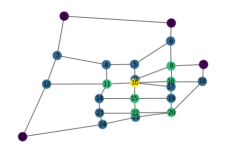

```python
nx.draw(G, pos, with_labels = True, node_color = list(centralities['degree_centr']))
```

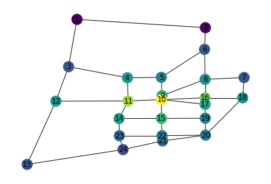

```python
nx.draw(G, pos, with_labels = True, node_color = list(centralities['closeness_centr']))
```

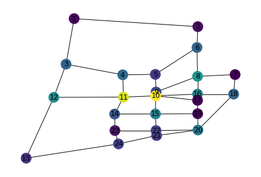

```python
nx.draw(G, pos, with_labels = True, node_color = list(centralities['betweenness_centr']))
```

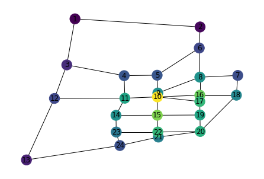

```python
nx.draw(G, pos, with_labels = True, node_color = list(centralities['eigenvector_centr']))
```

We can observe that there is quite a lot of similarity in the relative distribution of colors, but with some notable differences in the central nodes. That is to be expected, as each centrality measure has its own distinct definition (and purpose!).